# Notes for next time:

Figure out a way to pass the "district" column and "incumbent/challenger" columns back into my existing dataframes...Graph them, look for interesting stuff.

-Make list of things to ask FEC/search on the website. Start with definitions of some of these columns...who is doing what in some of these?

```
+ Also include what the general timeframe for the data is...Is this stuff specific for the U.S. presidential? How is it collected? And where would any errors be?
```

## Story Ideas....

1. Basic lists of who got the most monetary contributions. Do I keep it simple with individual ones? Or after I learn what some of these other columns do, do I try and add values together?
2. Why so many null values? Shell candidates?
3. Any other kinds of data sets I could try and thread in? Like population of some of these districts?
4. This might be a bit down the road...but maybe building a database that records donations by which social causes they support/antagonize?

```python
import pandas as pd
import matplotlib
import statistics
```

```python
df = pd.read_csv("weball20.txt", sep="|", header=None)
df.columns = ["CandidateID", "Name", "Incumbet_Challenger_Status", "Party_Code", "Party_Affiliation",
             "Total_Receipts", "Transfers_from_auth_committees", "Total_Disbursements", "Transfer_to_auth_committee",
             "Beginning_Cash", "Ending_Cash", "Contributions_from_candidate", "Loans_from_candidate", "Other_loans",
             "Candidate_loan_repayments","Other_loan_repayments","Debts_owed_by","Total_individual_contributions",
             "state","district","Special_Election_Status","Primary_election_status",
             "Runoff_election_status","General_election_status","General_election_percentage","Contributions_from_other_p.c.",
             "Contributions_from_party_committees","Coverage_end_date","Refunds_to_individuals","Refunds_to_commitees"]
```

```python
df.columns
```

```
Index(['CandidateID', 'Name', 'Incumbet_Challenger_Status', 'Party_Code',
       'Party_Affiliation', 'Total_Receipts', 'Transfers_from_auth_committees',
       'Total_Disbursements', 'Transfer_to_auth_committee', 'Beginning_Cash',
       'Ending_Cash', 'Contributions_from_candidate', 'Loans_from_candidate',
       'Other_loans', 'Candidate_loan_repayments', 'Other_loan_repayments',
       'Debts_owed_by', 'Total_individual_contributions', 'state', 'district',
       'Special_Election_Status', 'Primary_election_status',
       'Runoff_election_status', 'General_election_status',
       'General_election_percentage', 'Contributions_from_other_p.c.',
       'Contributions_from_party_committees', 'Coverage_end_date',
       'Refunds_to_individuals', 'Refunds_to_commitees'],
      dtype='object')
```

### I picked out a few column names that looked interesting.

```python
df[['Name','Party_Affiliation','Total_Receipts','Contributions_from_candidate',
    'Total_individual_contributions',
   'state','district','General_election_status']]
```

|  | Name | Party_Affiliation | Total_Receipts | Contributions_from_candidate | Total_individual_contributions | state | district | General_election_status |
| --- | --- | --- | --- | --- | --- | --- | --- | --- |
| 0 | SHEIN, DIMITRI | DEM | 0.00 | 0.00 | 0.00 | AK | 0 | NaN |
| 1 | YOUNG, DONALD E | REP | 1799862.78 | 0.00 | 889062.39 | AK | 0 | NaN |
| 2 | NELSON, THOMAS JOHN | REP | 0.00 | 0.00 | 0.00 | AK | 0 | NaN |
| 3 | GALVIN, ALYSE | IND | 4450799.47 | 3898.76 | 4110760.47 | AK | 0 | NaN |
| 4 | AVERHART, JAMES | DEM | 69347.96 | 0.00 | 40802.96 | AL | 1 | NaN |
| ... | ... | ... | ... | ... | ... | ... | ... | ... |
| 3953 | HOLTHUS, ROLLAND SCOTT MR | REP | 4291.94 | 0.00 | 0.00 | WY | 0 | NaN |
| 3954 | HARDY, CHARLES E | REP | 0.00 | 0.00 | 0.00 | WY | 0 | NaN |
| 3955 | MILLER, BRYAN | REP | 50876.53 | 0.00 | 16290.00 | WY | 0 | NaN |
| 3956 | BARRASSO, JOHN A | REP | 883945.37 | 0.00 | 481931.05 | WY | 0 | NaN |
| 3957 | ENZI, MICHAEL B | REP | 141784.99 | 0.00 | 16625.00 | WY | 0 | NaN |

3958 rows × 8 columns

## I picked out PA specific stuff

```python
df_pa = df[ df['state'] == 'PA' ][['Name','Party_Affiliation','district','Total_Receipts',
                          'Total_individual_contributions','Contributions_from_candidate',
                         'General_election_status']]
```

## PA DEM stuff

What I'm hoping the cell below does is take all of the DEMs that ran in the recent election and sorts them by who received the most individual campaign contributions, leading with the greatest amount.

```python
df_pa_dem = df_pa[ df['Party_Affiliation'] == 'DEM'][['Name','Total_individual_contributions']].sort_values(by='Total_individual_contributions',ascending=False)

df_pa_dem
```

|  | Name | Total_individual_contributions |
| --- | --- | --- |
| 2348 | WILD, SUSAN | 3209997.79 |
| 2372 | DEPASQUALE, EUGENE | 3113775.57 |
| 2417 | LAMB, CONOR | 2975013.88 |
| 2355 | CARTWRIGHT, MATTHEW A. | 2212644.52 |
| 2338 | HOULAHAN, CHRISSY | 1994849.67 |
| ... | ... | ... |
| 2329 | WERTIME, DAVID | 0.00 |
| 2394 | MARGOLIES-MEZVINSKY, MARJORIE | 0.00 |
| 2395 | ARKOOSH, VALERIE ANN | 0.00 |
| 2328 | LI, LINDY | 0.00 |
| 3818 | MCGINTY, KATHLEEN ALANA | 0.00 |

66 rows × 2 columns

## Here's a graph of most money received by DEM candidates...via individual contributions.

Note to self: Figure out why there are so many null values. Shell candidates just so the dems could run someone?

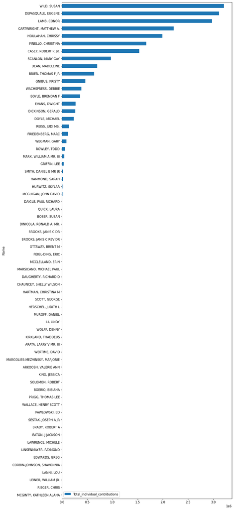

```python
df_pa_dem.sort_values(by='Total_individual_contributions', na_position='first').plot(x='Name',kind='barh',figsize=(10,30))
```

## Now, let's do the same thing for the REPs

```python
df_pa_rep = df_pa[ df['Party_Affiliation'] == 'REP'][['Name','Total_individual_contributions']].sort_values(by='Total_individual_contributions',ascending=False)

df_pa_rep
```

|  | Name | Total_individual_contributions |
| --- | --- | --- |
| 3821 | TOOMEY, PATRICK JOSEPH | 3283064.55 |
| 2378 | PERRY, SCOTT | 2897685.08 |
| 2421 | PARNELL, RICHARD SEAN | 2651730.19 |
| 2317 | FITZPATRICK, BRIAN | 1690372.07 |
| 2405 | RESCHENTHALER, GUY MR. | 1293523.30 |
| 2390 | KELLER, FRED | 1004848.45 |
| 2360 | BOGNET, JIM | 988565.42 |
| 2351 | SCHELLER, LISA | 910108.80 |
| 2324 | BARNETTE, KATHY | 807638.78 |
| 2409 | THOMPSON, GLENN MR. | 748292.76 |
| 2415 | KELLY, GEORGE J JR | 611585.77 |
| 2369 | MEUSER, DANIEL | 424807.50 |
| 2342 | EMMONS, JOHN MR. | 361291.17 |
| 2383 | SMUCKER, LLOYD K. | 341779.72 |
| 2400 | JOYCE, JOHN | 320109.62 |
| 2357 | DANIELS, TEDDY | 240554.39 |
| 2354 | BROWNING, DEAN NAPIER | 183880.60 |
| 2358 | GRANVILLE, EARL | 145047.67 |
| 2335 | PRUETT, DASHA | 75388.30 |
| 2419 | TIMKO, SCOTT RICHARD | 67334.18 |
| 2316 | MEEHAN, ANDREW | 57313.12 |
| 2427 | NEGRON, LUKE | 46008.56 |
| 2420 | THOMSEN, BRIAN | 30984.70 |
| 2377 | JEFFRIES, ROBERT | 17565.00 |
| 2356 | HAAS, HARRY | 13982.00 |
| 2340 | SIEDENBUEHL, THOMAS | 10425.10 |
| 2361 | CAMMISA, MIKE | 9639.00 |
| 2336 | JORDAN, ROBERT | 5210.00 |
| 2337 | BILLIE, JOSEPH MICHAEL | 3112.26 |
| 2370 | UEHLINGER, SCOTT | 2000.00 |
| 2391 | MCLINKO, DOUG | 100.00 |
| 2363 | CHRIN, JOHN R | 25.01 |
| 2410 | MACKENZIE, RYAN EDWARD | 0.00 |
| 2398 | HALVORSON, ARTHUR L | 0.00 |
| 2418 | ROTHFUS, KEITH MR. | 0.00 |
| 2422 | GEISSINGER, GLENN A | 0.00 |
| 3819 | CHRISTIAN, DAVID | 0.00 |
| 3820 | WELCH, STEVEN D | 0.00 |
| 2399 | EICHELBERGER, JOHN H. JR. | 0.00 |
| 3822 | VODVARKA, JOSEPH JOHN | 0.00 |
| 2368 | HALCOVAGE, GEORGE F. JR. | 0.00 |
| 2397 | SCHOOLEY, TRAVIS | 0.00 |
| 2389 | WHEELAND, JEFF C. | 0.00 |
| 2321 | ENGLISH, PHILIP S. | 0.00 |
| 2325 | DAVID, DAN | 0.00 |
| 2339 | COSTELLO, RYAN A | 0.00 |
| 2341 | STERN, EVERETT MR. | 0.00 |
| 2343 | GERLACH, JIM | 0.00 |
| 2344 | MCCAULEY, GREGORY MICHAEL | 0.00 |
| 2349 | WELCH, STEVEN D | 0.00 |
| 2350 | MEEHAN, PATRICK L. MR | 0.00 |
| 2352 | CONNOLLY, MATTHEW D | 0.00 |
| 2353 | NOTHSTEIN, MARTY MR. | 0.00 |
| 2359 | MARSICANO, MICHAEL | 0.00 |
| 2362 | FITZPATRICK, MICHAEL G. | 0.00 |
| 2367 | REED, DAVE | 0.00 |
| 2384 | BEILER, CHET | 0.00 |
| 2388 | MARINO, THOMAS ANTHONY | 0.00 |
| 3823 | CHRISTIANA, JAMES JOSEPH III | 0.00 |

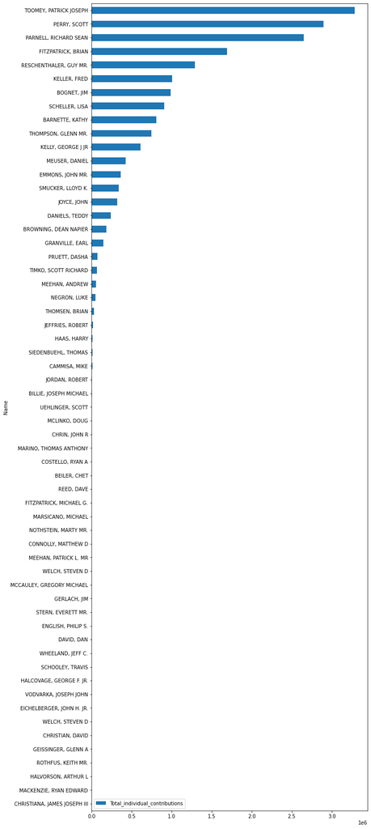

```python
df_pa_rep.sort_values(by='Total_individual_contributions', na_position='first').plot(x='Name',kind='barh',figsize=(10,30))
```

## Averages

Means, medians, quartiles...fun stuff like that. DEMs first, then REPs. (With nulls taken out)

```python
df_pa_dem_noNulls = df_pa_dem[ df_pa_dem['Total_individual_contributions'] > 0.01]
df_pa_dem_noNulls.describe()
```

|  | Total_individual_contributions |
| --- | --- |
| count | 3.500000e+01 |
| mean | 6.161906e+05 |
| std | 9.724810e+05 |
| min | 1.500000e+02 |
| 25% | 9.121020e+03 |
| 50% | 1.211159e+05 |
| 75% | 6.683985e+05 |
| max | 3.209998e+06 |

```python
df_pa_rep_noNulls = df_pa_rep[ df_pa_rep['Total_individual_contributions'] > 0.01]
df_pa_rep_noNulls.describe()
```

|  | Total_individual_contributions |
| --- | --- |
| count | 3.200000e+01 |
| mean | 6.013742e+05 |
| std | 8.840222e+05 |
| min | 2.501000e+01 |
| 25% | 1.666925e+04 |
| 50% | 2.122175e+05 |
| 75% | 8.332563e+05 |
| max | 3.283065e+06 |

```python
df.columns
```

```
Index(['CandidateID', 'Name', 'Incumbet_Challenger_Status', 'Party_Code',
       'Party_Affiliation', 'Total_Receipts', 'Transfers_from_auth_committees',
       'Total_Disbursements', 'Transfer_to_auth_committee', 'Beginning_Cash',
       'Ending_Cash', 'Contributions_from_candidate', 'Loans_from_candidate',
       'Other_loans', 'Candidate_loan_repayments', 'Other_loan_repayments',
       'Debts_owed_by', 'Total_individual_contributions', 'state', 'district',
       'Special_Election_Status', 'Primary_election_status',
       'Runoff_election_status', 'General_election_status',
       'General_election_percentage', 'Contributions_from_other_p.c.',
       'Contributions_from_party_committees', 'Coverage_end_date',
       'Refunds_to_individuals', 'Refunds_to_commitees'],
      dtype='object')
```